# 2-eda-2

Univariate distributions of key metrics

Authors

Oleksandr Koval

Andriy Koval

The report explores univariate distributions of key variables

**Load packages used in report**

```r
library(tidyverse)
library(ggplot2)
library(dplyr)
library(readr)


library(TabularManifest)
```

**Input data**

```r
ds3 <- readRDS("../../data-private/derived/university-ranking/1-scribe-ds3.rds")
#file_path <- "/data-private/derived/university-ranking/"
glimpse(ds3)
```

```
Rows: 201
Columns: 36
$ school_id                <dbl> 1, 2, 3, 4, 5, 6, 7, 8, 9, 10, 11, 12, 13, 14…
$ school_name              <chr> "Національний  технічний  університет  Україн…
$ rank_2024                <dbl> 1, 2, 3, 4, 5, 6, 7, 8, 9, 10, 11, 12, 13, 14…
$ index_2024               <dbl> 4.66, 4.94, 5.14, 5.93, 5.98, 7.43, 11.12, 11…
$ qs_rank                  <dbl> 3, 1, 4, 2, 4, 5, 6, 4, 5, 5, 7, 7, 4, 7, 7, …
$ qs_index                 <dbl> 0.45, 0.15, 0.60, 0.30, 0.60, 0.75, 0.90, 0.6…
$ scopus_rank              <dbl> 5, 1, 9, 2, 6, 3, 21, 11, 4, 24, 30, 7, 23, 3…
$ scopus_index             <dbl> 0.65, 0.13, 1.17, 0.26, 0.78, 0.39, 2.73, 1.4…
$ webometrics_rank         <dbl> 1, 3, 11, 9, 2, 10, 6, 8, 32, 7, 20, 15, 37, …
$ webometrics_index        <dbl> 0.1, 0.3, 1.1, 0.9, 0.2, 1.0, 0.6, 0.8, 3.2, …
$ uimpact_rank             <dbl> 5, 6, 2, 4, 1, 5, 6, 4, 4, 4, 6, 5, 6, 4, 6, …
$ uimpact_index            <dbl> 0.625, 0.750, 0.250, 0.500, 0.125, 0.625, 0.7…
$ wur_rank                 <dbl> 4, 4, 2, 4, 1, 4, 5, 4, 6, 3, 6, 4, 6, 6, 6, …
```

[output cut: 23 more lines]

# Defenitions

Index of the university is a numerical value produce by adding rank positions that were weighted by experts, lower number correspond to better university. The value of index ranges from 4.66 to 66.42.

```r
ds3$index_2024 %>% summary()
```

```
   Min. 1st Qu.  Median    Mean 3rd Qu.    Max.
   4.66   28.00   42.60   40.30   53.34   66.42
```

The rank of university represents the positions in this list.

# Indexes

## Key indices to observe

1. Type of Skewness (left, right, symmetric)
2. Modality( unimodal, bimodal, uniform)
3. Mean
4. Median
5. Standard deviation
6. Mode (where possible)
7. Interquartile Range (IQR)

**Function for mode**

```r
mode_values <- function(x) {
  tbl <- table(x)
  max_freq <- max(tbl)
  return(as.numeric(names(tbl)[tbl == max_freq]))  # Return all modes
}
```

## Index variable

**Statistical properties of index_2024 variable**

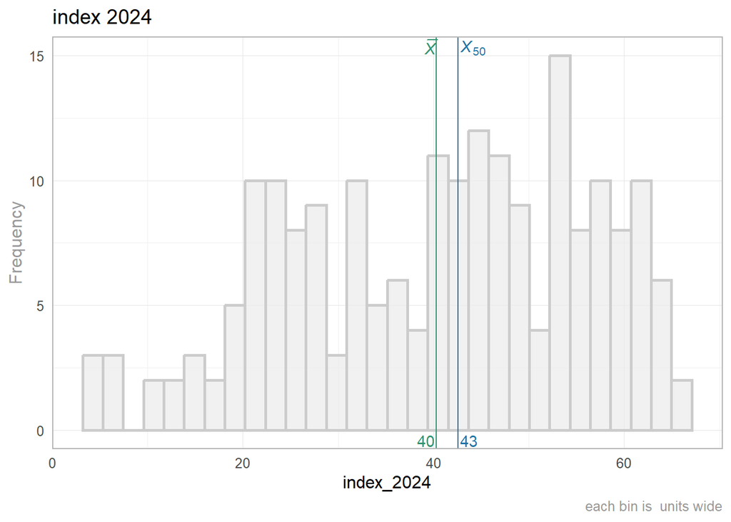

```r
# ds3 %>%
#   ggplot(aes(x = index_2024)) +
#   geom_histogram()

ds3 %>% TabularManifest::histogram_continuous("index_2024")
```

**Statistical properties of index_2024 variable**

```r
# ds3 %>% select(index_2024) %>%
#   tableone::CreateTableOne(data = .)

ds3 %>%
  summarise(
    index_mean = mean(index_2024)
    , index_sd = sd(index_2024)
    , index_median = median(index_2024)
    , index_iqr = IQR(index_2024)
    , index_mode = mode_values(index_2024)
  )
```

```
# A tibble: 1 × 5
  index_mean index_sd index_median index_iqr index_mode
       <dbl>    <dbl>        <dbl>     <dbl>      <dbl>
1       40.3     15.5         42.6      25.3       44.7
```

Modality: **Bimodal**

Skewness: **Left**

Mean: **40.3021741**

Standart Deviation: **15.5307933**

Median: **42.6**

IQR: **25.34**

Mode: **44.74**

## Scopus index

**Statistical properties of scopus_index variable**

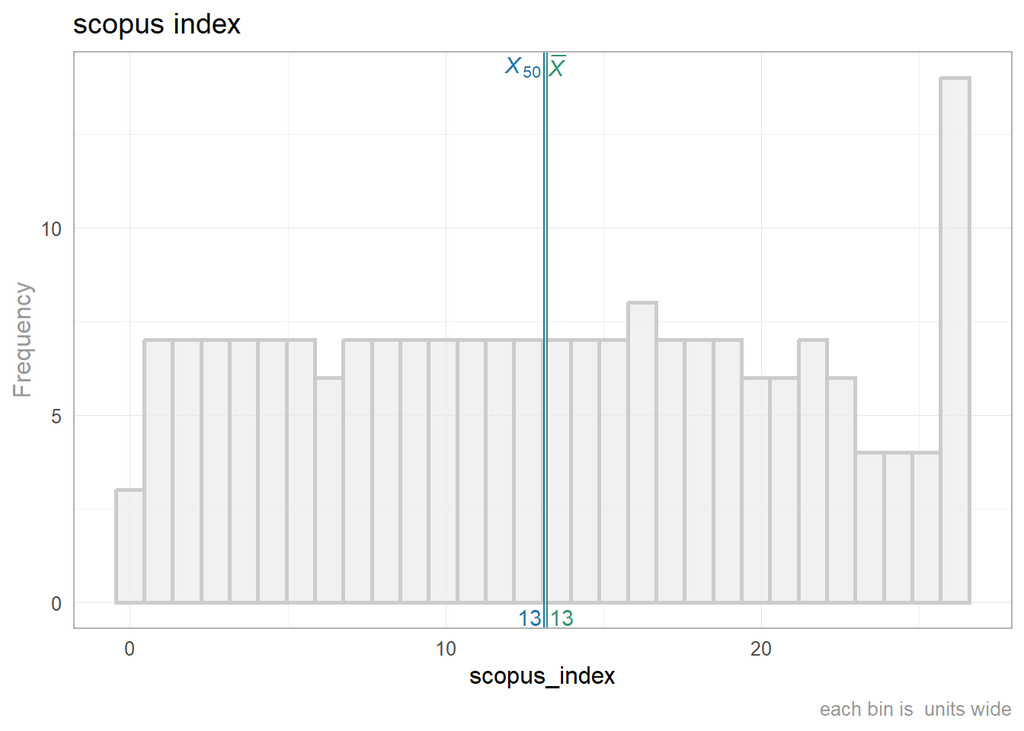

```r
ds3 %>% TabularManifest::histogram_continuous("scopus_index")
```

**Statistical properties of scopus_index variable**

```r
ds3 %>% summarise(
  scopus_mean = mean(scopus_index)
  , scopus_sd = sd(scopus_index)
  , scopus_median = median(scopus_index)
  , scopus_iqr = IQR(scopus_index)
  , scopus_mode = mode_values(scopus_index)
) %>% print.table()
```

```
  scopus_mean     scopus_sd scopus_median    scopus_iqr   scopus_mode
     13.22184      7.724504         13.13         12.87         26.26
```

Modality: **Uniform**

Skewness: **Symmetric**

Mean: **13.2218408**

Standart Deviation: **7.7245037**

Median: **13.13**

IQR: **12.87**

Mode: **26.26**

## Webometrics index

**Statistical properties of webometrics_index variable**

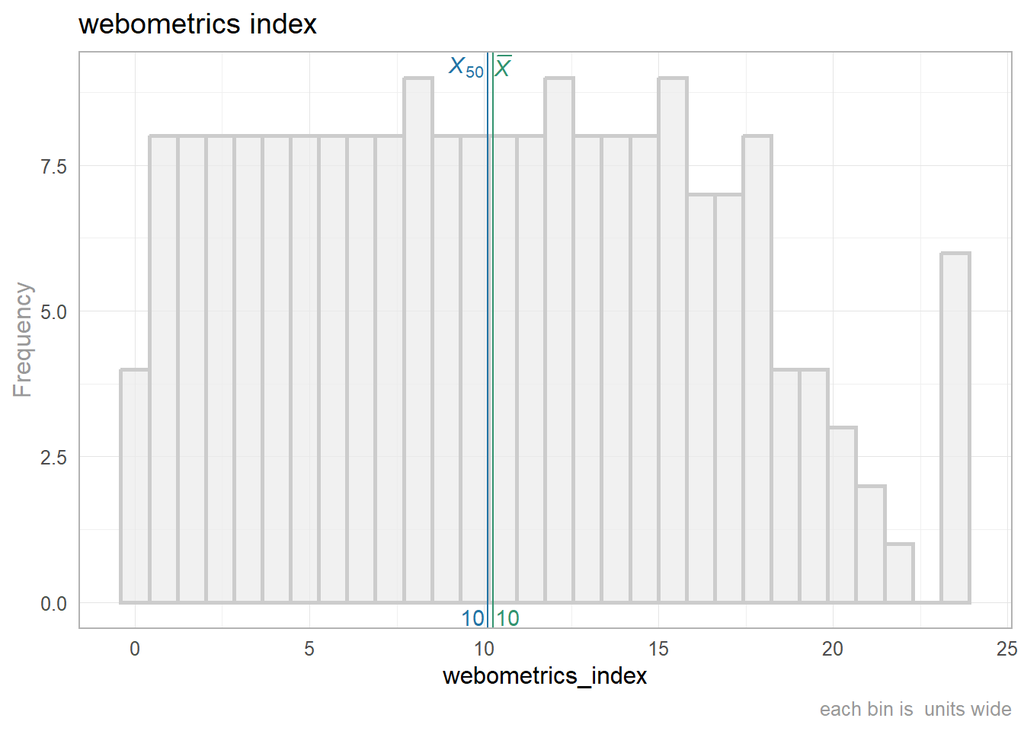

```r
ds3 %>% TabularManifest::histogram_continuous("webometrics_index")
```

**Statistical properties of webometrics_index variable**

```r
ds3 %>% summarise(
  webometrics_mean = mean(webometrics_index)
  ,webometrics_sd = sd(webometrics_index)
  , webometrics_median = median(webometrics_index)
  , webometrics_iqr = IQR(webometrics_index)
  , webometrics_mode = mode_values(webometrics_index)
) %>% print.table()
```

```
  webometrics_mean     webometrics_sd webometrics_median    webometrics_iqr
          10.26219           6.130715               10.1                9.9
  webometrics_mode
              23.6
```

Modality: **Uniform**

Skewness: **Right**

Mean: **10.2621891**

Standart Deviation: **6.1307147**

Median: **10.1**

IQR: **9.9**

Mode: **23.6**

## Competition index

**Statistical properties of competition_index variable**

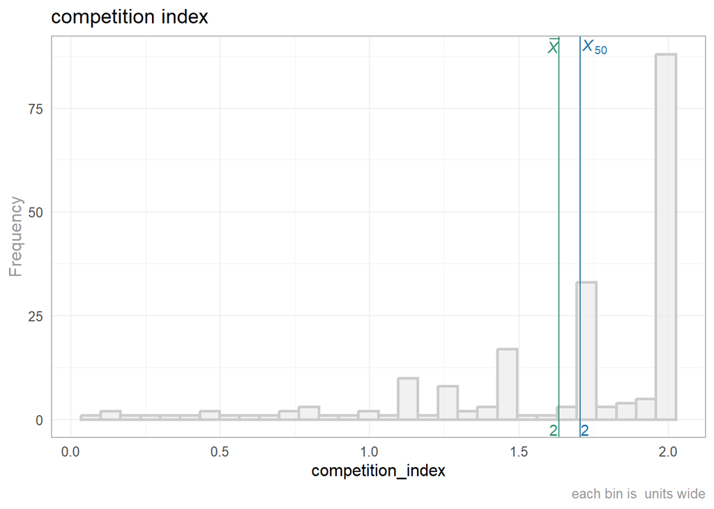

```r
ds3 %>% TabularManifest::histogram_continuous("competition_index")
```

**Statistical properties of competition_index variable**

```r
ds3 %>% summarise(
  competition_mean = mean(competition_index)
  , competition_sd = sd(competition_index)
  , competition_median = median(competition_index)
  , competition_iqr = IQR(competition_index)
  , competition_mode = mode_values(competition_index)
) %>% print.table()
```

```
  competition_mean     competition_sd competition_median    competition_iqr
          1.633308          0.4593157              1.705              0.495
  competition_mode
              1.98
```

Modality: **Five peaks**

Skewness: **Left**

Mean: **1.6333085**

Standart Deviation: **0.4593157**

Median: **1.705**

IQR: **0.495**

Mode: **1.98**

## Naqa index

**Statistical properties of naqa_index variable**

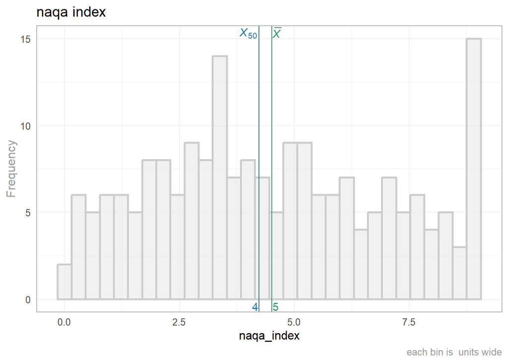

```r
ds3 %>% TabularManifest::histogram_continuous("naqa_index")
```

**Statistical properties of naqa_index variable**

```r
ds3 %>% summarise(
  naqa_mean = mean(naqa_index)
  , naqa_sd = sd(naqa_index)
  , naqa_median = median(naqa_index)
  , naqa_iqr = IQR(naqa_index)
  , naqa_mode = mode_values(naqa_index)
) %>% print.table()
```

```
  naqa_mean     naqa_sd naqa_median    naqa_iqr   naqa_mode
   4.518756    2.547334       4.235        4.07       8.965
```

Modality: **Bimodal**

Skewness: **Right**

Mean: **4.5187562**

Standart Deviation: **2.5473341**

Median: **4.235**

IQR: **4.07**

Mode: **8.965**

## Patent index

**Statistical properties of patent_index variable**

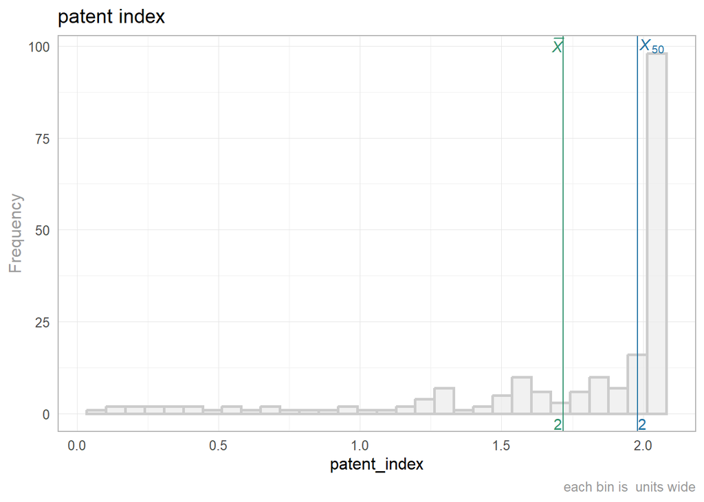

```r
ds3 %>% TabularManifest::histogram_continuous("patent_index")
```

**Statistical properties of patent_index variable**

```r
ds3 %>% summarise(
  patent_mean = mean(patent_index)
  , patent_sd = sd(patent_index)
  , patent_median = median(patent_index)
  , patent_iqr = IQR(patent_index)
  , patent_mode = mode_values(patent_index)
) %>% print.table()
```

```
  patent_mean     patent_sd patent_median    patent_iqr   patent_mode
     1.716766     0.5039603          1.98          0.44         2.035
```

Modality: **Unimodal**

Skewness: **Left**

Mean: **1.7167662**

Standart Deviation: **0.5039603**

Median: **1.98**

IQR: **0.44**

Mode: **2.035**

## Mean index

**Statistical properties of mean_index variable**

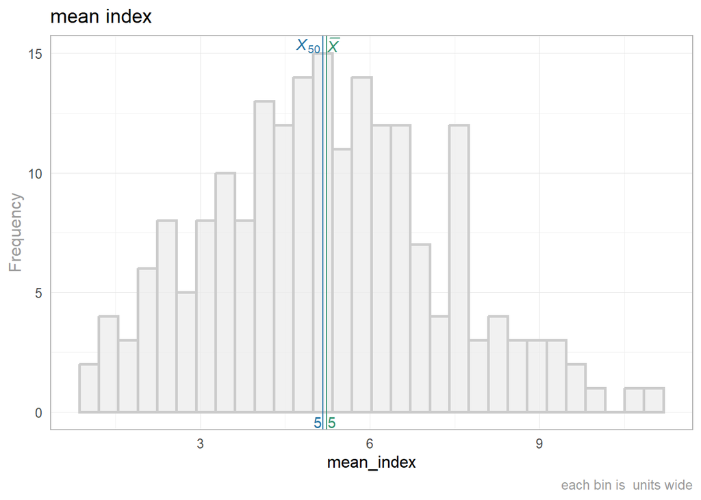

```r
ds3 %>% TabularManifest::histogram_continuous("mean_index")
```

**Statistical properties of mean_index variable**

```r
ds3 %>% summarise(
  mean_mean = mean(mean_index)
  , mean_sd = sd(mean_index)
  , mean_median = median(mean_index)
  , mean_iqr = IQR(mean_index)
  #, mean_mode = mode_values(mean_index)
) %>% print.table()
```

```
  mean_mean     mean_sd mean_median    mean_iqr
   5.237453    2.071129        5.17       2.832
```

**Statistical properties of mean_index variable**

```r
ds3 %>% summarise(
  mean_mode = mode_values(mean_index)
)
```

```
# A tibble: 2 × 1
  mean_mode
      <dbl>
1      4.81
2      5.17
```

Modality: **Unimodal**

Skewness: **Symmetric**

Mean: **5.2374527**

Standart Deviation: **2.0711293**

Median: **5.17**

IQR: **2.832**

Mode: **4.813, 5.17**

# Another variables

## Department count

**Statistical properties of department_count variable**

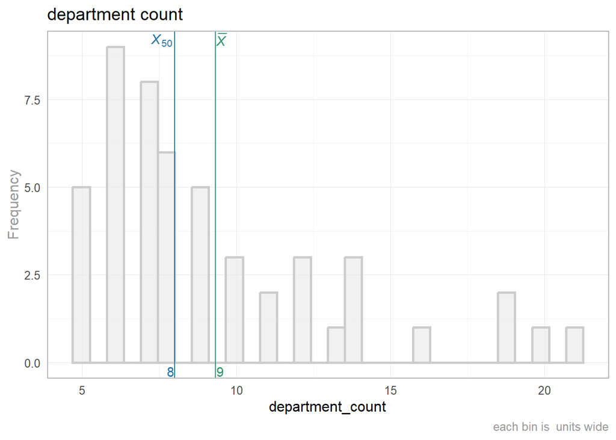

```r
ds3 %>%
  filter(
    department_count == na.omit(department_count)
  ) %>%
  select(department_count) %>%
TabularManifest::histogram_continuous("department_count")
```

**Statistical properties of department_count variable**

```r
ds3 %>%
  filter(
    rank_2024 <= 50
    # , department_count == na.omit(department_count)
  ) %>%
  select(department_count) %>%
  summarise(
    department_mean = mean(department_count)
    ,department_sd = sd(department_count)
    , department_median = median(department_count)
    , department_iqr = IQR(department_count)
    , department_mode = mode_values(department_count)
  )
```

```
# A tibble: 1 × 5
  department_mean department_sd department_median department_iqr department_mode
            <dbl>         <dbl>             <dbl>          <dbl>           <dbl>
1            9.32          4.13                 8              5               6
```

**Statistical properties of department_count variable**

```r
ds1 <-
  ds3 %>%
   filter(
    rank_2024 <= 50
    # , department_count == na.omit(department_count)
  )
```

Modality: **Unimodal**

Skewness: **Right**

Mean: **9.32**

Standart Deviation: **4.1326969**

Median: **8**

IQR: **5**

Mode: **6**

## Program count

**Statistical properties of program_count variable**

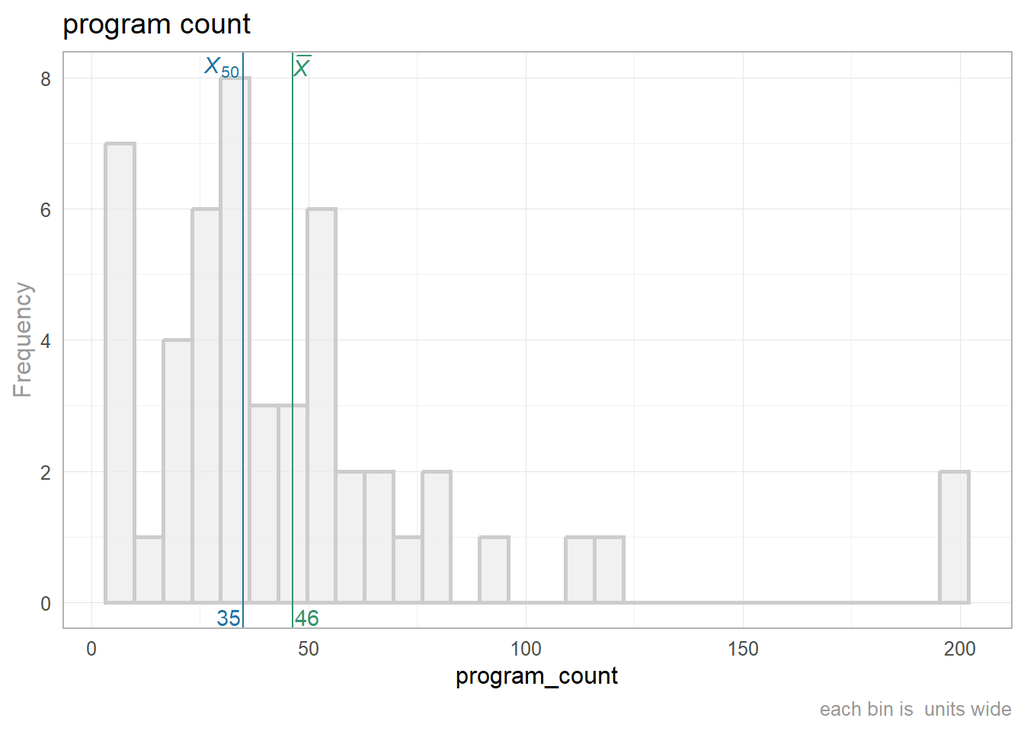

```r
ds3 %>%
  filter(
    program_count == na.omit(program_count)
  ) %>%
  select(program_count) %>%
TabularManifest::histogram_continuous("program_count")
```

**Statistical properties of program_count variable**

```r
ds3 %>%
  filter(
    rank_2024 <= 50
    # , department_count == na.omit(department_count)
  ) %>%
  select(program_count) %>%
  summarise(
    program_mean = mean(program_count)
    ,program_sd = sd(program_count)
    , program_median = median(program_count)
    , program_iqr = IQR(program_count)
    , program_mode = mode_values(program_count)
  )
```

```
# A tibble: 1 × 5
  program_mean program_sd program_median program_iqr program_mode
         <dbl>      <dbl>          <dbl>       <dbl>        <dbl>
1         46.3       40.7             35        29.8           25
```

Modality: **Unimodal**

Skewness: **Right**

Mean: **46.3**

Standart Deviation: **40.6715314**

Median: **35**

IQR: **29.75**

**Statistical properties of population of the city variable**

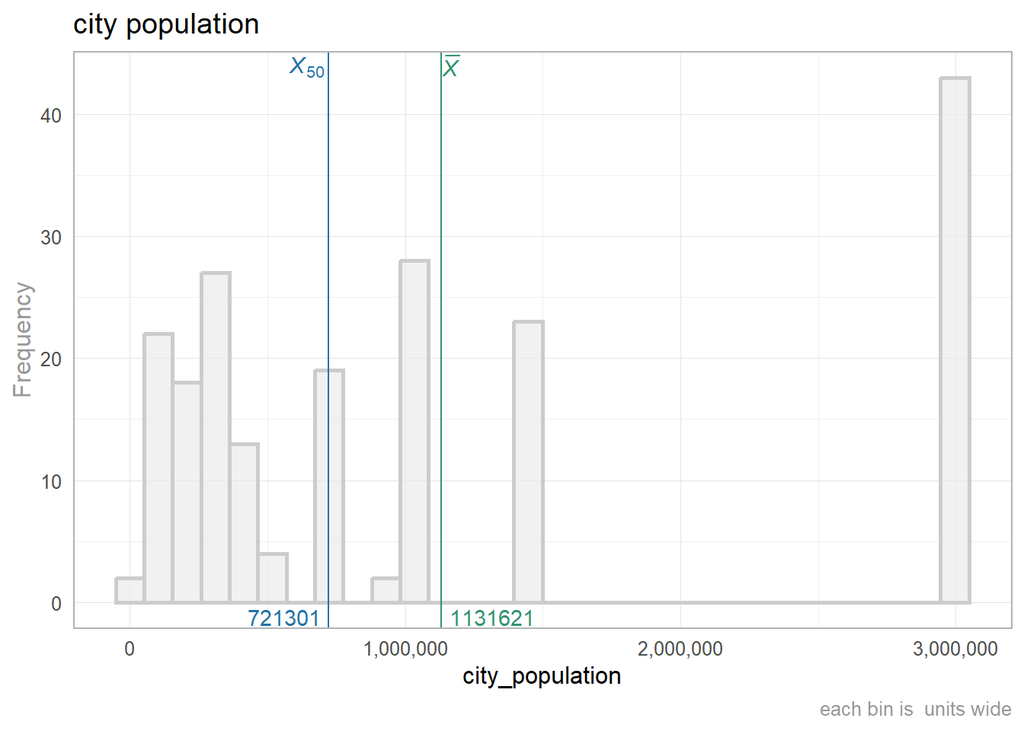

```r
ds3 %>% TabularManifest::histogram_continuous("city_population")
```

**Statistical properties of population of the city variable**

```r
ds1 <-
ds3 %>%
  summarise(
    city_mean = format(mean(city_population),  big.mark = ",")
    , city_sd = format(sd(city_population),  big.mark = ",")
    , city_median = format(median(city_population),  big.mark = ",")
    , city_iqr = format(IQR(city_population),  big.mark = ",")
    , city_mode = format(mode_values(city_population),  big.mark = ",")
  ) %>% print.table()
```

```
  city_mean     city_sd city_median    city_iqr   city_mode
  1,131,621   1,066,510     721,301   1,147,980   3,020,000
```

Skewness: **Right**

Mean: **1,131,621**

Standart Deviation: **1,066,510**

Median: **721,301**

IQR: **1,147,980**

Mode: **3,020,000**

## Applicaion total count

**Statistical properties of total number of applications variable**

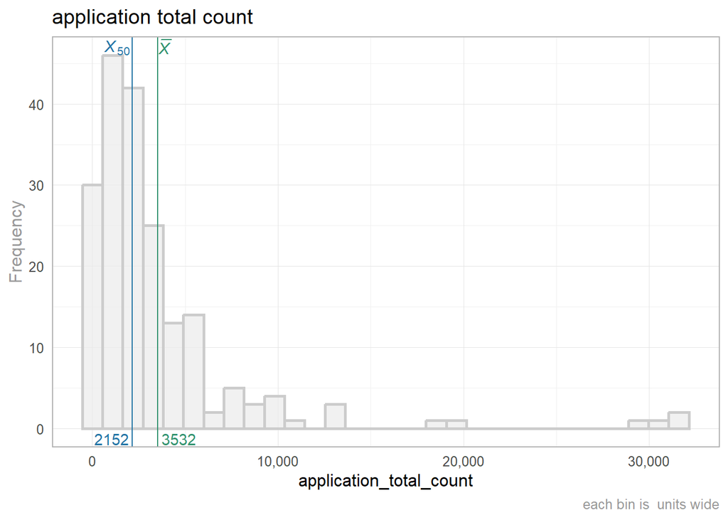

```r
ds3 %>% TabularManifest::histogram_continuous("application_total_count")
```

```r
ds3$application_budget_count %>% mode_values()
```

```
[1] 458 564
```

**Statistical properties of total number of applications variable**

```r
ds1 <-
ds3 %>%
  filter(!is.na(application_total_count)) %>%
  reframe(
    application_total_count_mean = mean(application_total_count)
    , application_total_count_sd = sd(application_total_count)
    , application_total_count_median = median(application_total_count)
    , application_total_count_iqr = IQR(application_total_count)
    , #application_total_count_mode = mode_values(application_total_count)
  ) %>% slice(1) %>% print.table()
```

```
  application_total_count_mean     application_total_count_sd
                      3531.845                       5011.178
application_total_count_median    application_total_count_iqr
                          2152                           3033
```

Modality: **Unimodal**

Skewness: **Right**

Mean: **3531.8453608**

Standart Deviation: **5011.1779361**

Median: **2152**

IQR: **3033**

## Score mean

**Statistical properties of score_mean variable**

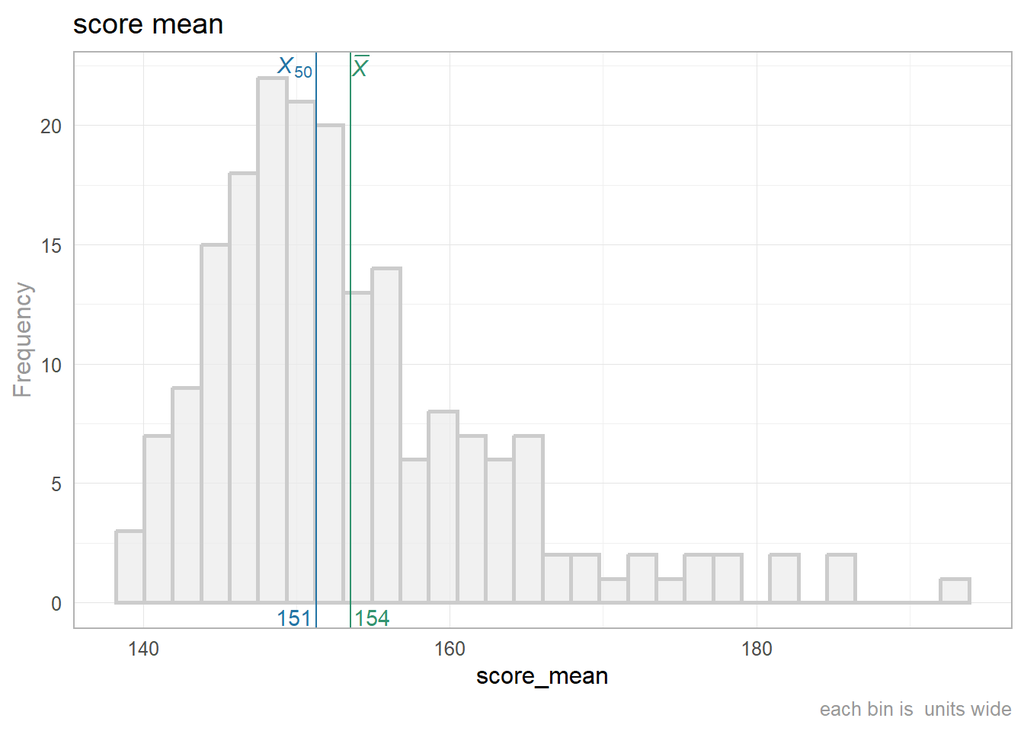

```r
ds3 %>% TabularManifest::histogram_continuous("score_mean")
```

**Statistical properties of score_mean variable**

```r
ds1 <- ds3$score_mean %>%
  na.omit()

ds3 %>%
  summarise(
    score_mean_mean = mean(score_mean, na.rm = TRUE),
    score_sd = sd(score_mean, na.rm = TRUE),
    score_median = median(score_mean, na.rm = TRUE),
    score_iqr = IQR(score_mean, na.rm = TRUE),
    score_mode = mode_values(score_mean)
  )
```

```
# A tibble: 10 × 5
   score_mean_mean score_sd score_median score_iqr score_mode
             <dbl>    <dbl>        <dbl>     <dbl>      <dbl>
 1            154.     9.53         151.      10.4       144.
 2            154.     9.53         151.      10.4       145.
 3            154.     9.53         151.      10.4       147.
 4            154.     9.53         151.      10.4       148.
 5            154.     9.53         151.      10.4       148.
 6            154.     9.53         151.      10.4       149.
 7            154.     9.53         151.      10.4       150.
 8            154.     9.53         151.      10.4       151.
 9            154.     9.53         151.      10.4       153.
10            154.     9.53         151.      10.4       160.
```